# OrthoFinder tutorial for BUG

Javier F. Tabima

February 12, 2020

# Objectives

Assessments of homology using genomic data allow for the identification of genes under selection, expansion or reduction of genic families, analysis of presence or absence of important genes, and identification of core genes across different taxonomic levels. These assays based on orthologous gene searches come in different flavors, and many tools have been created to identify homologous genes across different genomes (e.g. OrthoMCL, InParanoid, FastOrtho, etc).

In this tutorial we will focus on OrthoFinder (Emms et al. 2015; https://genomebiology.biomedcentral.com/articles/10.1186/s13059-015-0721-2), a fast and simple software focused on phylogenetic orthology inference. We will focus on the basics of this program, how to run it in the cluster, and how to interpret results to identify core homologous genes, genic duplication and how OrthoFinder reconstructs species trees based on orthologous gene data.

# Data sets

OrthoFinder uses **protein sequences** in FASTA format and it performs optimally on protein sequences predicted from whole genome sequences. For this tutorial we want to explore orthology across the Eukaryotic tree of life. We will use **six different species across the tree of life**:

- *Canis lupus* (Dog)
- *Amanita muscaria* (Fly agaric)
- *Phytophthora infestans* (Late blight of potato and tomato)
- *Arabidopsis thaliana* (thale cress)
- *Dyctiostelium discoideum* (Cellular slime mold)
- *Paramecium tetraurelia*

# Procedure

## Obtaining data

1. Download all of the samples to a folder in the cluster. The folder can be any folder that you have access to. In my case, I’ll download everything in my `home/` folder

```
cd ~
mkdir orthofinder_test
cd orthofinder_test
```

2. To download these files into the structure you can either download them all separately or one by one. Here are the commands I use:

```
SGE_Batch -c 'curl ftp://ftp.ncbi.nlm.nih.gov/genomes/all/GCF/000/002/285/GCF_000002285.3_CanFam3.1/GCF_000002285.3_CanFam3.1_protein.faa.gz > Canis_lupus.fasta.gz' -r curl_1
SGE_Batch -c 'curl ftp://ftp.ncbi.nlm.nih.gov/genomes/all/GCA/000/827/485/GCA_000827485.1_Amanita_muscaria_Koide_BX008_v1.0/GCA_000827485.1_Amanita_muscaria_Koide_BX008_v1.0_protein.faa.gz > Amanita_muscaria.fasta.gz' -r curl_2
SGE_Batch -c 'curl ftp://ftp.ncbi.nlm.nih.gov/genomes/all/GCF/000/142/945/GCF_000142945.1_ASM14294v1/GCF_000142945.1_ASM14294v1_protein.faa.gz  > Phytophthora_infestans.fasta.gz' -r curl_3
SGE_Batch -c 'curl ftp://ftp.ncbi.nlm.nih.gov/genomes/all/GCF/000/001/735/GCF_000001735.4_TAIR10.1/GCF_000001735.4_TAIR10.1_protein.faa.gz > Arabidopsis_thaliana.fasta.gz' -r curl_4
SGE_Batch -c 'curl ftp://ftp.ncbi.nlm.nih.gov/genomes/all/GCF/000/004/695/GCF_000004695.1_dicty_2.7/GCF_000004695.1_dicty_2.7_protein.faa.gz > Dyctiostelium_discoideum.fasta.gz' -r curl_5
SGE_Batch -c 'curl ftp://ftp.ncbi.nlm.nih.gov/genomes/all/GCF/000/165/425/GCF_000165425.1_ASM16542v1/GCF_000165425.1_ASM16542v1_protein.faa.gz > Paramecium_tetraurelia.fasta.gz' -r curl_6
```

3. Decompress the fasta files

```
SGE_Batch -c 'bash; for i in *.gz; do gunzip $i; done' -r gunzip
```

4. Remove all the unnecessary files

```
rm -rf curl_*/
rm -rf gunzip/
```

## Summary of data

To estimate the number of proteins per downloaded genome we can count the number of sequences in each of the FASTA files we downloaded. To do so you can count the number of `>` characters per file. This is how I would do it:

```
for i in *.fasta; do a=$(grep -c ">" $i); printf $i"\t"$a"\n"; done
```

The results should look like this:

| FASTA file | Number of proteins |
| --- | --- |
| Amanita_muscaria.fasta | 18,093 |
| Arabidopsis_thaliana.fasta | 48,265 |
| Canis_lupus.fasta | 58,774 |
| Dyctiostelium_discoideum.fasta | 13,315 |
| Paramecium_tetraurelia.fasta | 39,580 |
| Phytophthora_infestans.fasta | 17,797 |

# Downloading Orthofinder

- Download the latest OrthoFinder.tar.gz release from github:

```
cd ~
wget https://github.com/davidemms/OrthoFinder/releases/latest/download/OrthoFinder.tar.gz
```

- Extract the files:

```
tar xzf OrthoFinder.tar.gz
```

- Test OrthoFinder:

```
cd OrthoFinder/
./orthofinder -h
```

If OrthoFinder works correctly, OrthoFinder should print its ‘help’ text.

# Running OrthoFinder

For this example, we will run OrthoFinder using the default settings. One of the greatest advantages of OrthoFinder is that the only input it requires is the folder where the FASTA sequences are. In our case, the FASTA aminoacid files are contained in the `~/orthofinder_test` folder. *Make sure you have the absolute path of your folder. In my example, the path is* `/raid1/home/bpp/tabimaj/orthofinder_test`

```
SGE_Batch -c './orthofinder -f /raid1/home/bpp/tabimaj/orthofinder_test -t 8' -P 8 -r BUG_orthofinder
```

# OrthoFinder results

The run of OrthoFinder took 2h 20mins using eight threads at the CGRB infrastructure. The host which was OrthoFinder ran at was `symbiosis`.

The results of your personal OrthoFinder run should be found in the `~/orthofinder_test/Results_Feb12/` folder. For an example run, I have a folder that will CGRB users read the files from an identical OrthoFinder folder at `/raid1/home/bpp/tabimaj/orthofinder_test/OrthoFinder/Results_Feb06_1`

While I recommend you to go to the [OrthoFinder webpage](https://github.com/davidemms/OrthoFinder) to understand what files and results come as output from the program, we will focus in four main results today:

- The **Statistics Overall** file
- The **Statistics Per Species** file
- The count of genes per **Orthogroup** predicted by OrthoFinder
- The **Single copy orthologs** and the **Species Tree**

## Statistics Overall

> Location: `/raid1/home/bpp/tabimaj/orthofinder_test/OrthoFinder/Results_Feb06_1/Comparative_Genomics_Statistics/Statistics_Overall.tsv`

The **Statistics Overall** file is a tab-separated text file that contains general statistics about orthogroup sizes and proportion of genes assigned to orthogroups.

As mentioned by the [OrthoFinder webpage](https://github.com/davidemms/OrthoFinder):

> Most of the terms in the files ‘Statistics_Overall.csv’ and ‘Statistics_PerSpecies.csv’ are self-explanatory, the remainder are defined below.

> Species-specific orthogroup: An orthogroups that consist entirely of genes from one species.

> G50: The number of genes in the orthogroup such that 50% of genes are in orthogroups of that size or larger.

> O50: The smallest number of orthogroups such that 50% of genes are in orthogroups of that size or larger.

> Single-copy orthogroup: An orthogroup with exactly one gene (and no more) from each species. These orthogroups are ideal for inferring a species tree and many other analyses.

> Unassigned gene: A gene that has not been put into an orthogroup with any other genes.

Lets take a look at the file. Even if this is a “tab-separated” file, we need to split it on sections:

#### Section 1: Overall statistics (Lines 1 to 24)

```r
library(magrittr)
library(knitr)
library(kableExtra)

knitr::kable(read.table("Results/Statistics_Overall.tsv",fill = T, nrows = 24, sep = "\t")) %>%
 kable_styling(bootstrap_options = c("striped", "hover", "condensed", "responsive"))
```

| V1 | V2 |
| --- | --- |
| Number of species | 6 |
| Number of genes | 195824 |
| Number of genes in orthogroups | 172946 |
| Number of unassigned genes | 22878 |
| Percentage of genes in orthogroups | 88.3 |
| Percentage of unassigned genes | 11.7 |
| Number of orthogroups | 25731 |
| Number of species-specific orthogroups | 19632 |
| Number of genes in species-specific orthogroups | 111223 |
| Percentage of genes in species-specific orthogroups | 56.8 |
| Mean orthogroup size | 6.7 |
| Median orthogroup size | 4.0 |
| G50 (assigned genes) | 10 |
| G50 (all genes) | 9 |
| O50 (assigned genes) | 4442 |
| O50 (all genes) | 5664 |
| Number of orthogroups with all species present | 1319 |
| Number of single-copy orthogroups | 32 |
| Date | 2020-02-06 |
| Orthogroups file | Orthogroups.tsv |
| Unassigned genes file | Orthogroups_UnassignedGenes.tsv |
| Per-species statistics | Statistics_PerSpecies.tsv |
| Overall statistics | Statistics_Overall.tsv |
| Orthogroups shared between species | Orthogroups_SpeciesOverlaps.tsv |

##### Questions (Section 1):

1. What is the number of *orthogroups that consist entirely of genes from one species*? Is it the majority of data? What percentage of the orthogroups is is?
2. What is the number of *single-copy orthogroups* found in the analysis? What does this mean biologically?

#### Section 2: Genes per Orthogroup (Lines 26-45)

```r
genes_per_OG <- read.delim("Results/Statistics_Overall.tsv",fill = T, skip = 25, nrows = 20, sep = "\t")
kable(genes_per_OG) %>% kable_styling(bootstrap_options = c("striped", "hover", "condensed", "responsive"))
```

| Average.number.of.genes.per.species.in.orthogroup | Number.of.orthogroups | Percentage.of.orthogroups | Number.of.genes | Percentage.of.genes |
| --- | --- | --- | --- | --- |
| <1 | 16108 | 62.6 | 47651 | 27.6 |
| ’1 | 6015 | 23.4 | 47718 | 27.6 |
| ’2 | 1887 | 7.3 | 26446 | 15.3 |
| ’3 | 737 | 2.9 | 14887 | 8.6 |
| ’4 | 399 | 1.6 | 10460 | 6.0 |
| ’5 | 236 | 0.9 | 7651 | 4.4 |
| ’6 | 130 | 0.5 | 4987 | 2.9 |
| ’7 | 70 | 0.3 | 3103 | 1.8 |
| ’8 | 45 | 0.2 | 2268 | 1.3 |
| ’9 | 28 | 0.1 | 1569 | 0.9 |
| ’10 | 21 | 0.1 | 1297 | 0.7 |
| 11-15 | 44 | 0.2 | 3353 | 1.9 |
| 16-20 | 8 | 0.0 | 880 | 0.5 |
| 21-50 | 3 | 0.0 | 676 | 0.4 |
| 51-100 | 0 | 0.0 | 0 | 0.0 |
| 101-150 | 0 | 0.0 | 0 | 0.0 |
| 151-200 | 0 | 0.0 | 0 | 0.0 |
| 201-500 | 0 | 0.0 | 0 | 0.0 |
| 501-1000 | 0 | 0.0 | 0 | 0.0 |
| ’1001+ | 0 | 0.0 | 0 | 0.0 |

I think its easier to see these results on a plot than in the table

```r
library(reshape2)
library(tidyverse)
```

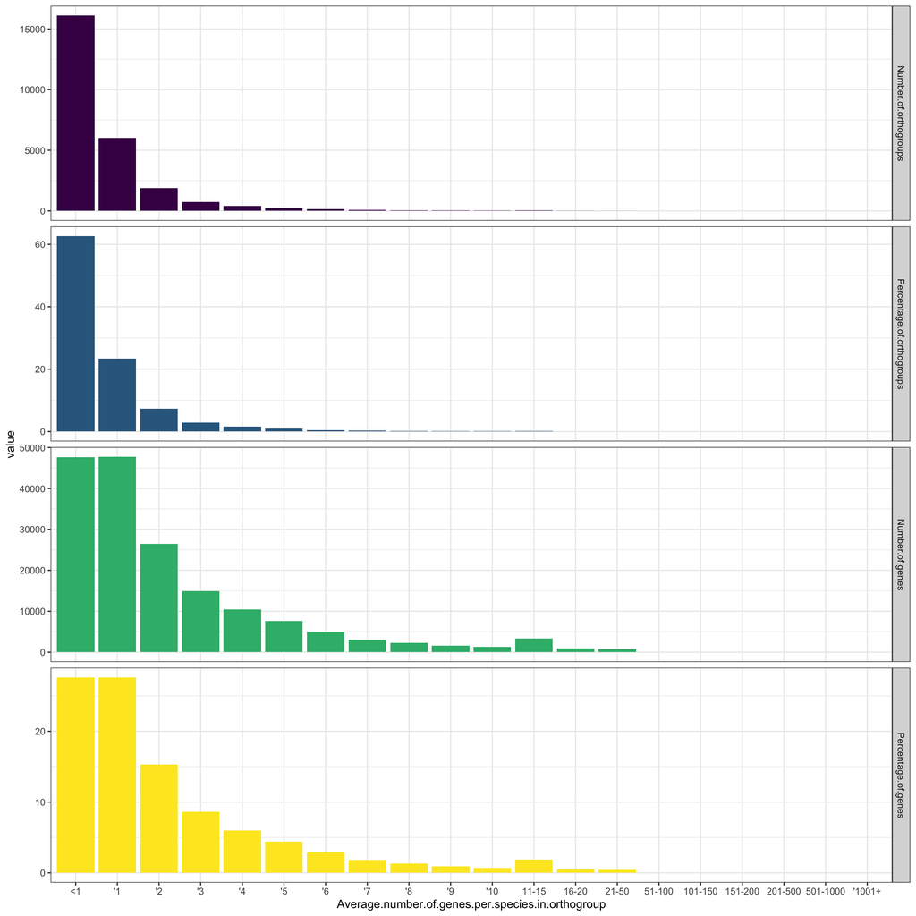

```r
genes_per_OG.m <- melt(genes_per_OG, id.vars = "Average.number.of.genes.per.species.in.orthogroup", factorsAsStrings = T)
genes_per_OG.m$Average.number.of.genes.per.species.in.orthogroup <- factor(genes_per_OG.m$Average.number.of.genes.per.species.in.orthogroup,levels = as.character(genes_per_OG$Average.number.of.genes.per.species.in.orthogroup))

ggplot(genes_per_OG.m, aes(x=Average.number.of.genes.per.species.in.orthogroup , y=value, fill=variable)) + geom_bar(stat="identity") + facet_grid(variable~., scales = "free_y") + scale_fill_viridis_d() + theme_bw() + theme(legend.position = "none")
```

##### Questions (Section 2):

1. What is the overall pattern of the results we find?

#### Section 3: Species per Orthogroup (Lines 47-54)

```r
species_per_OG <- read.delim("Results/Statistics_Overall.tsv",fill = T, skip = 46, nrows = 7, sep = "\t", header = T)
kable(species_per_OG) %>% kable_styling(bootstrap_options = c("striped", "hover", "condensed", "responsive"))
```

| Number.of.species.in.orthogroup | Number.of.orthogroups |
| --- | --- |
| 1 | 19632 |
| 2 | 2027 |
| 3 | 1128 |
| 4 | 774 |
| 5 | 851 |
| 6 | 1319 |

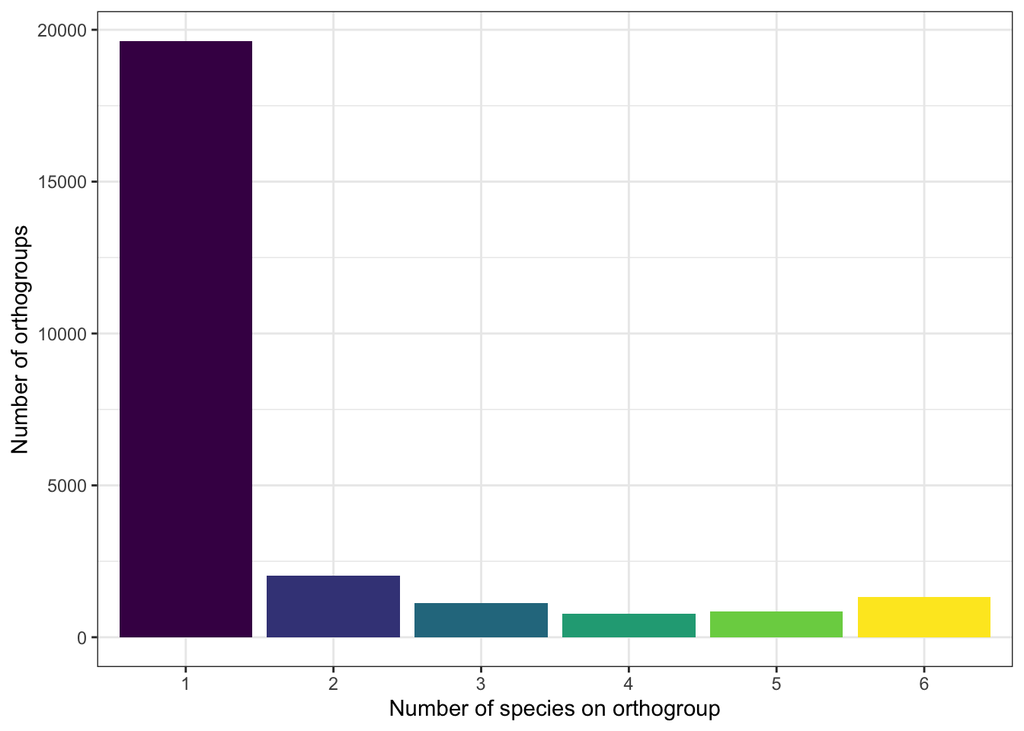

```r
ggplot(species_per_OG, aes(x=as.factor(Number.of.species.in.orthogroup), y=Number.of.orthogroups, fill=as.factor(Number.of.species.in.orthogroup))) + geom_bar(stat="identity") + scale_fill_viridis_d() + theme_bw() + theme(legend.position = "none")  + xlab("Number of species on orthogroup") + ylab("Number of orthogroups")
```

##### Questions (Section 3):

1. The highest number of orthogroups contain only one species. What are the biological implications of this result?
2. If OrthoFinder was used in a subset of highly-similar species, would this result be similar or would it change? How so?

## Statistics per Species

> Location: `/raid1/home/bpp/tabimaj/orthofinder_test/OrthoFinder/Results_Feb06_1/Comparative_Genomics_Statistics/Statistics_PerSpecies.tsv`

The **Statistics per Species** file is a tab-separated text file that contains general statistics about the number of genes that are within each category of orthogroups for each species. As with the **Statistics Overall** table, we have to divide it into different sections:

```r
overall_stats <- read.table("Results/Statistics_PerSpecies.tsv",fill = T, nrows = 10, sep = "\t", header = T)
species_names <- colnames(overall_stats)[-1]

knitr::kable(overall_stats) %>%
 kable_styling(bootstrap_options = c("striped", "hover", "condensed", "responsive"))
```

| X | Amanita_muscaria | Arabidopsis_thaliana | Canis_lupus | Dyctiostelium_discoideum | Paramecium_tetraurelia | Phytophthora_infestans |
| --- | --- | --- | --- | --- | --- | --- |
| Number of genes | 18093.0 | 48265.0 | 58774.0 | 13315.0 | 39580.0 | 17797.0 |
| Number of genes in orthogroups | 12895.0 | 44825.0 | 56239.0 | 9889.0 | 35093.0 | 14005.0 |
| Number of unassigned genes | 5198.0 | 3440.0 | 2535.0 | 3426.0 | 4487.0 | 3792.0 |
| Percentage of genes in orthogroups | 71.3 | 92.9 | 95.7 | 74.3 | 88.7 | 78.7 |
| Percentage of unassigned genes | 28.7 | 7.1 | 4.3 | 25.7 | 11.3 | 21.3 |
| Number of orthogroups containing species | 4719.0 | 8553.0 | 9321.0 | 4723.0 | 9480.0 | 5539.0 |
| Percentage of orthogroups containing species | 18.3 | 33.2 | 36.2 | 18.4 | 36.8 | 21.5 |
| Number of species-specific orthogroups | 1310.0 | 4665.0 | 4930.0 | 769.0 | 6636.0 | 1322.0 |
| Number of genes in species-specific orthogroups | 7616.0 | 28905.0 | 36927.0 | 4152.0 | 26548.0 | 7075.0 |
| Percentage of genes in species-specific orthogroups | 42.1 | 59.9 | 62.8 | 31.2 | 67.1 | 39.8 |

As these results are very numerous, lets graph them. We will do a subset of the non-percentage data first:

```r
overall_stats.number <- overall_stats[grep(x = overall_stats$X, pattern = "Number"),]
overall_stats.number <- melt(overall_stats.number)
```

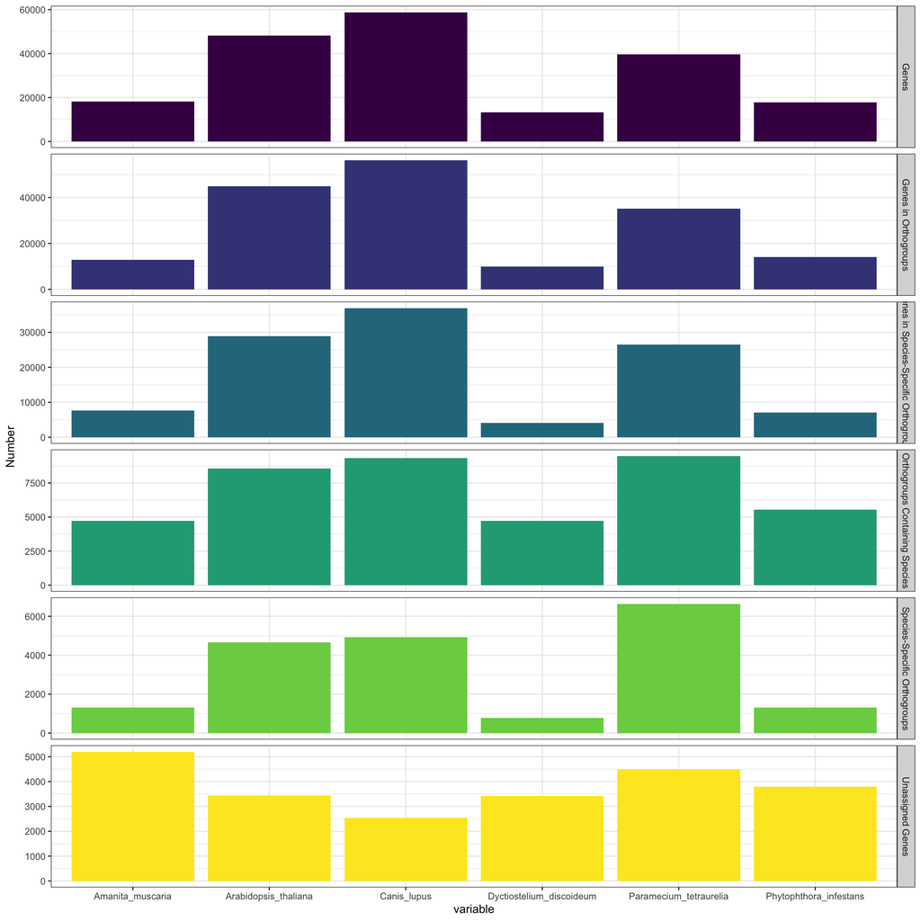

```r
overall_stats.number$X <- gsub(overall_stats.number$X, pattern = "Number of ", replacement = "") %>% tools::toTitleCase()

ggplot(overall_stats.number, aes(x=variable , y=value, fill=X)) + geom_bar(stat="identity") + facet_grid(X~., scales = "free_y") + scale_fill_viridis_d() + theme_bw() + theme(legend.position = "none") + ylab("Number")
```

##### Questions (Section 1 - Numeric results):

1. What is the species with the most and the least number of genes used in the analysis?
2. What does the *Species specific orthologs* category mean? Is this representing paralogy?
3. Does this table/plot accurately represent the contribution of each species to the orthology assay?

While the numeric results provide us with an overall assay of the general results of the orthologous assay, the data formatted in percentages may prove a more standardized vision of the results:

```r
overall_stats.percentage <- overall_stats[grep(x = overall_stats$X, pattern = "Number", invert = T),]
overall_stats.percentage <- melt(overall_stats.percentage)
```

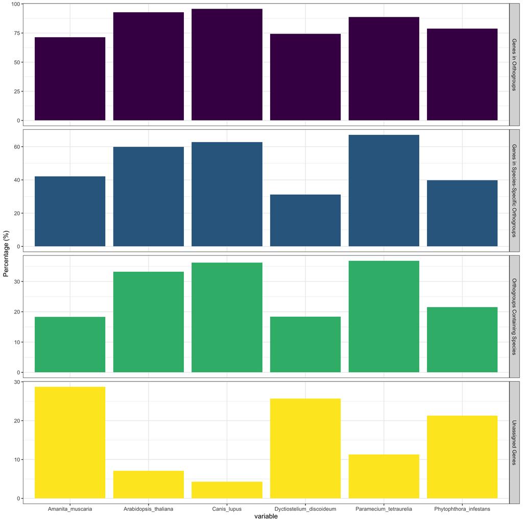

```r
overall_stats.percentage$X <- gsub(overall_stats.percentage$X, pattern = "Percentage of ", replacement = "") %>% tools::toTitleCase()

ggplot(overall_stats.percentage, aes(x=variable , y=value, fill=X)) + geom_bar(stat="identity") + facet_grid(X~., scales = "free_y") + scale_fill_viridis_d() + theme_bw() + theme(legend.position = "none") + ylab("Percentage (%)")
```

##### Questions (Section 1 - Percentage results):

1. What is the species with the most shared genes across the entire data set?

#### Section 2. Per species- per ortholog statistics (Lines 14 to 56)

The second section of the **Statistics per Species** file includes all the statistics of the number and percentage of orthologs that contain data for each species. For today we will focus only on the percentages (Lines 35 - 56):

```r
perecentage_stats <- read.delim("Results/Statistics_PerSpecies.tsv",fill = T, skip = 35, nrows = 20, sep = "\t", header = T)
colnames(perecentage_stats)[-1] <- species_names

knitr::kable(perecentage_stats) %>%
 kable_styling(bootstrap_options = c("striped", "hover", "condensed", "responsive"))
```

| Number.of.genes.per.species.in.orthogroup | Amanita_muscaria | Arabidopsis_thaliana | Canis_lupus | Dyctiostelium_discoideum | Paramecium_tetraurelia | Phytophthora_infestans |
| --- | --- | --- | --- | --- | --- | --- |
| ’0 | 81.7 | 66.8 | 63.8 | 81.6 | 63.2 | 78.5 |
| ’1 | 10.7 | 4.1 | 5.1 | 12.5 | 3.1 | 12.1 |
| ’2 | 3.6 | 8.9 | 6.8 | 3.1 | 16.0 | 4.7 |
| ’3 | 1.4 | 5.7 | 5.0 | 1.1 | 6.1 | 1.7 |
| ’4 | 0.7 | 3.7 | 3.7 | 0.5 | 4.4 | 0.9 |
| ’5 | 0.4 | 2.4 | 2.9 | 0.3 | 2.0 | 0.5 |
| ’6 | 0.3 | 1.8 | 2.1 | 0.2 | 1.5 | 0.3 |
| ’7 | 0.2 | 1.3 | 1.8 | 0.2 | 0.9 | 0.3 |
| ’8 | 0.1 | 0.9 | 1.4 | 0.1 | 0.6 | 0.2 |
| ’9 | 0.1 | 0.7 | 1.1 | 0.1 | 0.5 | 0.2 |
| ’10 | 0.1 | 0.5 | 0.9 | 0.1 | 0.2 | 0.1 |
| 11-15 | 0.3 | 1.5 | 2.5 | 0.2 | 0.7 | 0.3 |
| 16-20 | 0.1 | 0.7 | 1.1 | 0.1 | 0.3 | 0.2 |
| 21-50 | 0.2 | 1.1 | 1.5 | 0.1 | 0.4 | 0.2 |
| 51-100 | 0.0 | 0.1 | 0.1 | 0.0 | 0.1 | 0.0 |
| 101-150 | 0.0 | 0.0 | 0.0 | 0.0 | 0.0 | 0.0 |
| 151-200 | 0.0 | 0.0 | 0.0 | 0.0 | 0.0 | 0.0 |
| 201-500 | 0.0 | 0.0 | 0.0 | 0.0 | 0.0 | 0.0 |
| 501-1000 | 0.0 | 0.0 | 0.0 | 0.0 | 0.0 | 0.0 |
| ’1001+ | 0.0 | 0.0 | 0.0 | 0.0 | 0.0 | 0.0 |

```r
perecentage_stats$Number.of.genes.per.species.in.orthogroup <- factor(perecentage_stats$Number.of.genes.per.species.in.orthogroup, levels = perecentage_stats$Number.of.genes.per.species.in.orthogroup)

perecentage_stats <- melt(perecentage_stats)
```

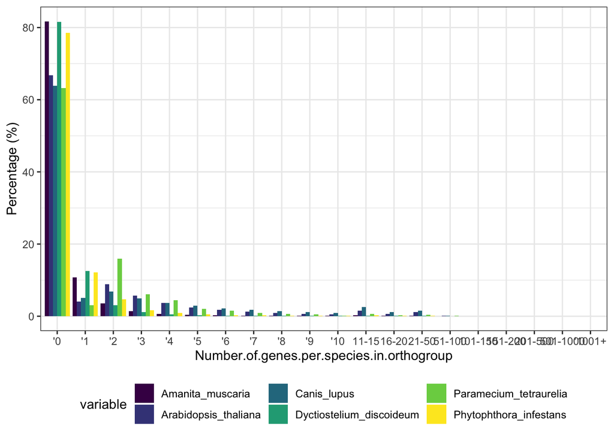

```r
ggplot(perecentage_stats, aes(x=Number.of.genes.per.species.in.orthogroup , y=value, fill=variable)) + geom_bar(stat="identity", position = "dodge") + scale_fill_viridis_d() + theme_bw() + theme(legend.position = "bottom") + ylab("Percentage (%)")
```

##### Questions (Section 2 - Percentage results):

1. Why are these results expected?